# Fish population trends in the rivers of Britanny

Results

2024-02-01

# 1 The dataset

## 1.1 The networks

From the overall dataset of the Aspe database, only 2 monitoring networks are considered here.

- Réseau de Contrôle de Surveillance (RCS)
- Réseau Hydrobiologique Piscicole (RHP)

The former two are monitoring networks considered representative of the diversity of the rivers ecosystems in continental France and operated unmodified since 2007. Pooled together, they are further referred to as “REPNET”. The RRP (perennial reference network) encompasses only minimally-impacted sites. It is operated unmodified since 2013, and further referred to as “REFNET”.

Note that one site can contribute to more than one network (true also for one survey).

## 1.2 Data selection

> *Are the sampling sites distributed evenly in space?*

The points sizes indicate the number of years the site has been surveyed.

[interactive chart not shown]

## 1.3 Sampling effort across time

How many sites sampled by year?

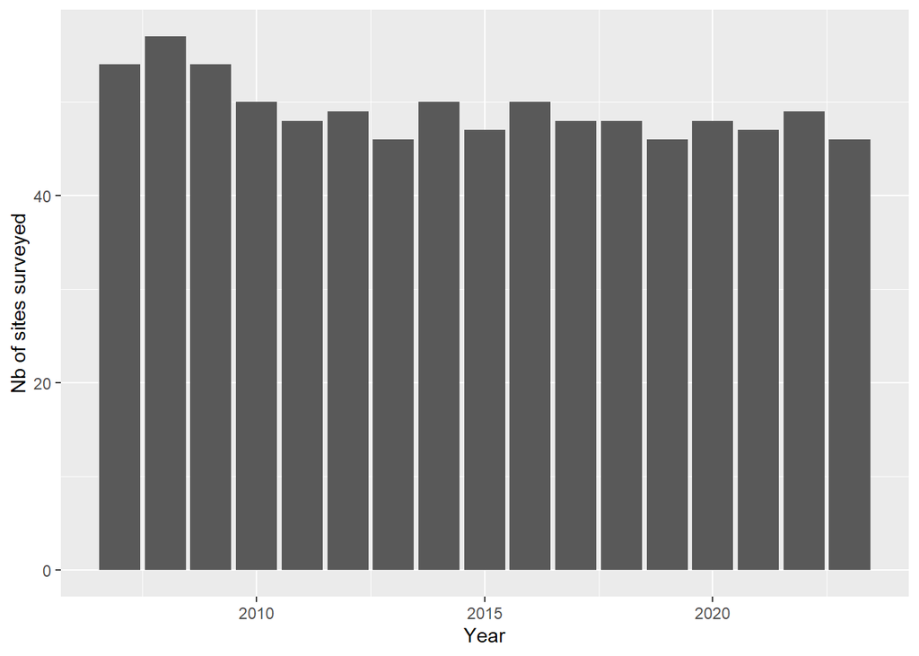

# 2 Populations trends

## 2.1 Time window for species assessmment

The Red List method is to assess population trends in a time lapse defined as the maximum between 10 years and 3 times the species generation time. The dataset, so far, starts in 2007 and ends in 2023 (17 annual data, allowing the study of trends on 16 annual intervals). Hence, for the species with a generation time 5 years (lapse 3 x 5y = 15y) or less, the dataset has to be filtered to exclude the oldest data.

| Species | Generation time | Years to assess | First year |
| --- | --- | --- | --- |
| Abramis brama | 5 | 15 | 2008 |
| Alburnus alburnus | 5 | 15 | 2008 |
| Barbatula barbatula | 5 | 15 | 2008 |
| Blicca bjoerkna | 4 | 12 | 2011 |
| Cottus spp | 3 | 10 | 2013 |
| Cyprinus carpio | 5 | 15 | 2008 |
| Esox lucius | 5 | 15 | 2008 |
| Gasterosteus aculeatus | 3 | 10 | 2013 |
| Gobio sp. | 3 | 10 | 2013 |
| Gymnocephalus cernua | 5 | 15 | 2008 |
| Lampetra planeri | 6 | 18 | 2007 |
| Leuciscus spp | 4 | 12 | 2011 |
| Perca fluviatilis | 4 | 12 | 2011 |
| Phoxinus sp. | 4 | 12 | 2011 |
| Pungitius pungitius | 3 | 10 | 2013 |
| Rutilus rutilus | 4 | 12 | 2011 |
| Salmo trutta | 3 | 10 | 2013 |
| Scardinius erythrophthalmus | 5 | 15 | 2008 |
| Squalius cephalus | 6 | 18 | 2007 |
| Tinca tinca | 5 | 15 | 2008 |

## 2.2 Nb of occurrences by year

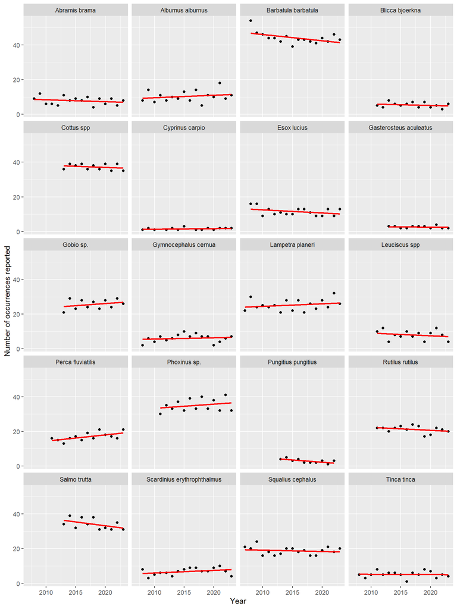

Figure 2.1: Annual number of occurrences by species, along with their regression lines.

## 2.3 Population indicators

[figure not shown]

Figure 2.2: Temporal trend in the fish populations indicators. Each point is the annual mean value of the indicator. Solid regression lines indicate that the Mann-Kendall trend test is significant at the 5% threshold. All the indicators for a given species are on a row.

# 3 Density trends at sites

To assess the significance of a monotonous temporal trend for each sampling point, a Mann-Kendall non-parametric test is performed. Sen-Theil slope is then estimated in order to retrieve its sign.

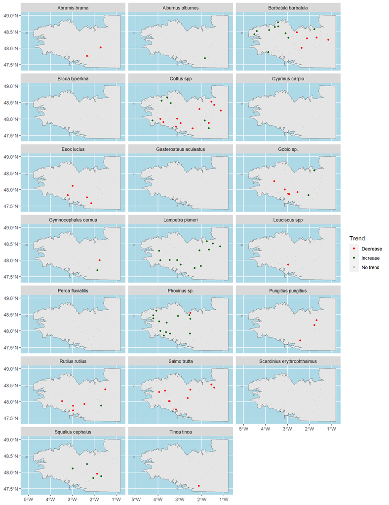

Figure 3.1: Temporal trend fish species densities assessed by Mann-Kendall test. The red and green points indicate the sites where densities significantly decrease and increase, respectively. The grey points indicate that the species is or has been present, but displays no significant trend. The sites where the species were never recorded are not displayed.